# 326.212 Homework 1

### Textbook 3.5.1

#### Problem 2. What do the empty cells in plot with facet_grid(drv ~ cyl) mean? How do they relate to this plot?

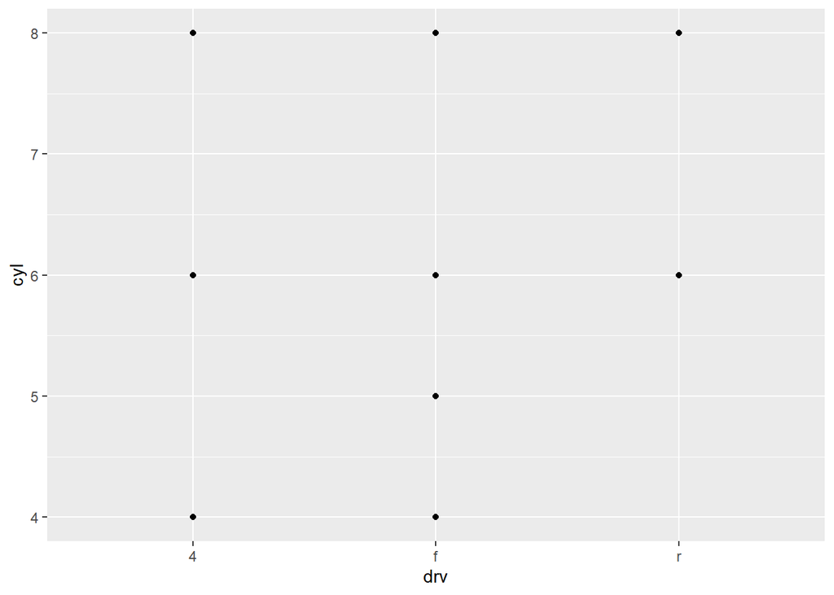

```r
ggplot(data = mpg) +
  geom_point(mapping = aes(x = drv, y = cyl))
```

빈 그리드는 `cyl`과 `drv`의 특정 조합에서 관측치가 없음을 알려준다. 이는 주어진 산점도에서 점이 찍히지 않은 부분에 해당한다.

#### Problem 6. When using facet_grid() you should usually put the variable with more unique levels in the columns.Why?

열에다가 값이 여러개 없는 변수를 두어야 열들 사이에 공간이 넓어진다. 이에 각 그리드의 가로부분이 길어질 것이므로 그래프의 추세 등을 더 잘 확인 할수 있을 것이다.

### Textbook 3.6.1

#### Problem 2. Run this code in your head and predict what the output will look like. Then, run the code in R and check your predictions.

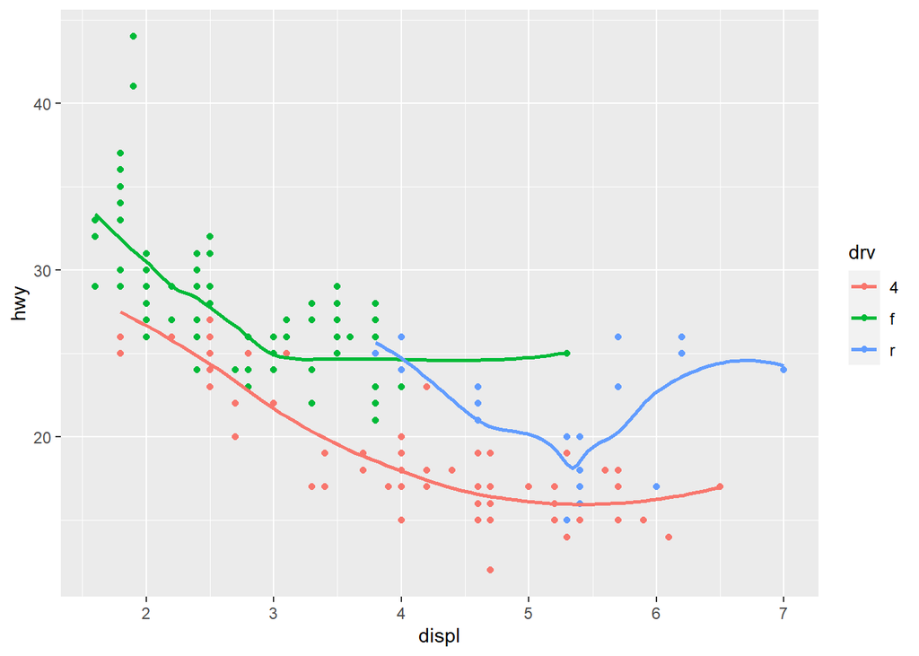

```r
ggplot(data = mpg, mapping = aes(x = displ, y = hwy, color = drv)) +
  geom_point() +
  geom_smooth(se = FALSE)
```

mpg 데이터들을 x축은 `displ`, y축은 `hwy`를 기준으로 점으로 배치할 것이고, drv에 따라 색을 달리 할 것이다. 그리고 각 `drv`에 해당하는 데이터들을 가장 잘 나타내는 선들이 그려질 것이다.

#### Problem 6. Recreate the R code necessary to generate the following graphs

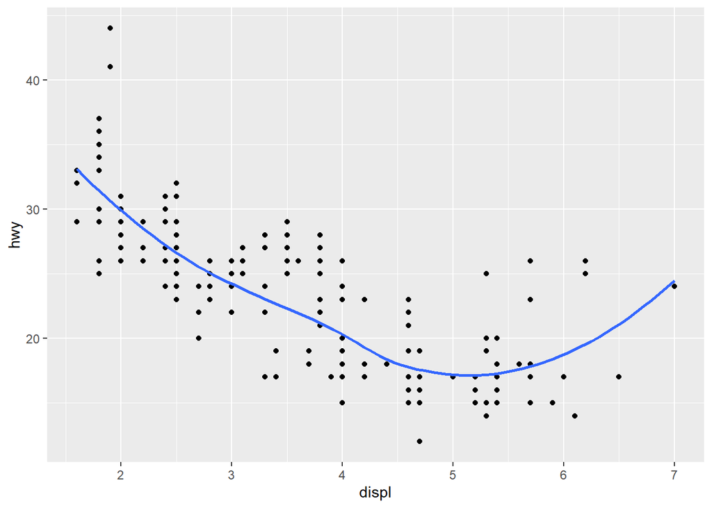

```r
ggplot(data = mpg, mapping = aes(x = displ, y = hwy)) +
  geom_point() +
  geom_smooth(se = FALSE)
```

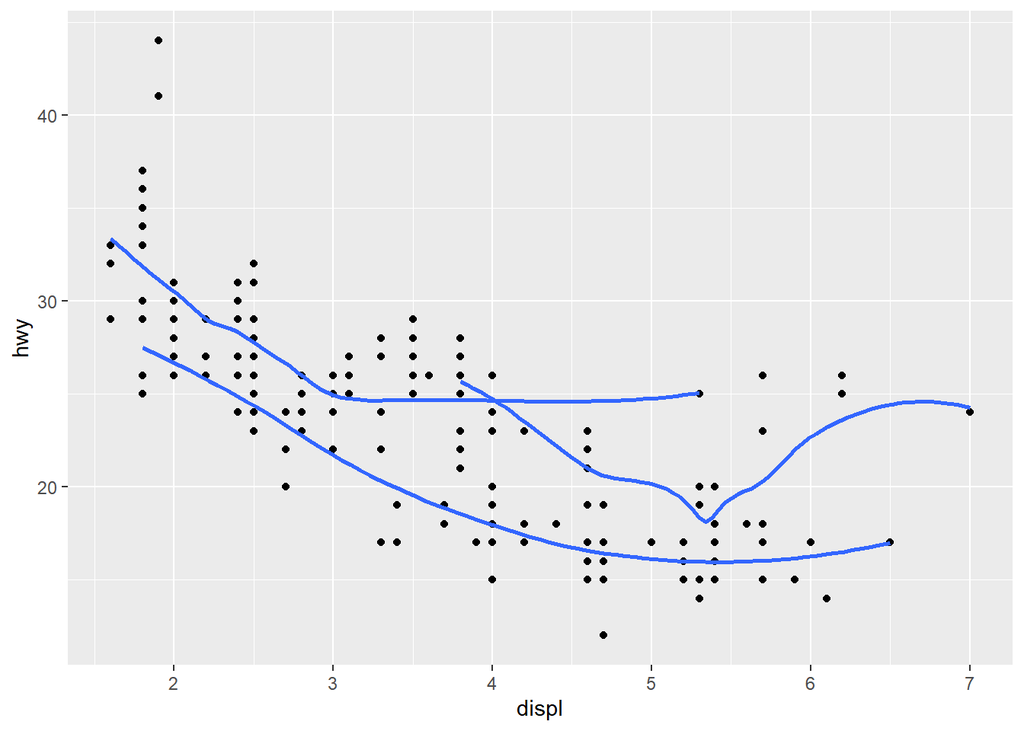

```r
ggplot(data = mpg, mapping = aes(x = displ, y = hwy)) +
  geom_point() +
  geom_smooth(mapping = aes(group = drv), se = FALSE)
```

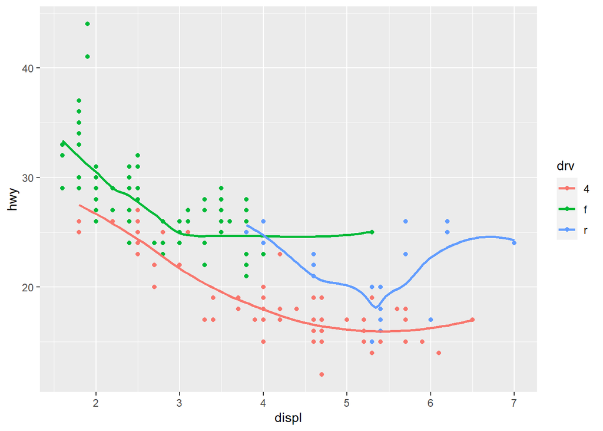

```r
ggplot(data = mpg, aes(x = displ, y = hwy, color = drv)) +
  geom_point() +
  geom_smooth(se = FALSE)
```

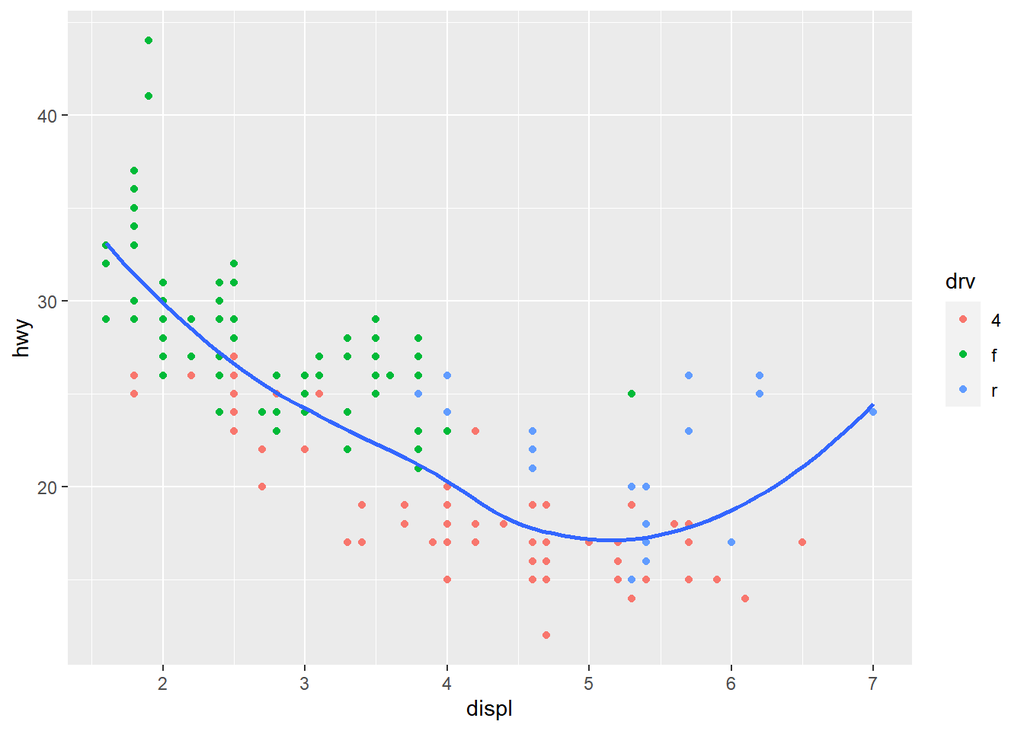

```r
ggplot(data = mpg, mapping = aes(x = displ, y = hwy)) +
  geom_point(mapping = aes(color=drv)) +
  geom_smooth(se = FALSE)
```

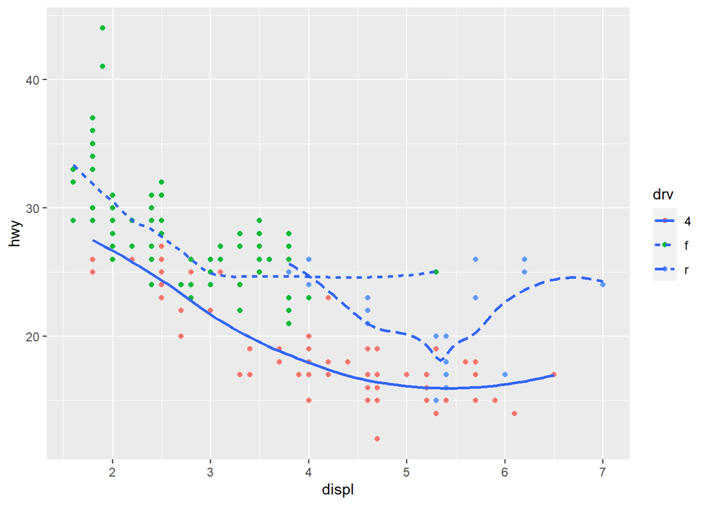

```r
ggplot(data = mpg, mapping = aes(x = displ, y = hwy)) +
  geom_point(mapping = aes(color=drv)) +
  geom_smooth(se = FALSE, mapping = aes(linetype = drv))
```

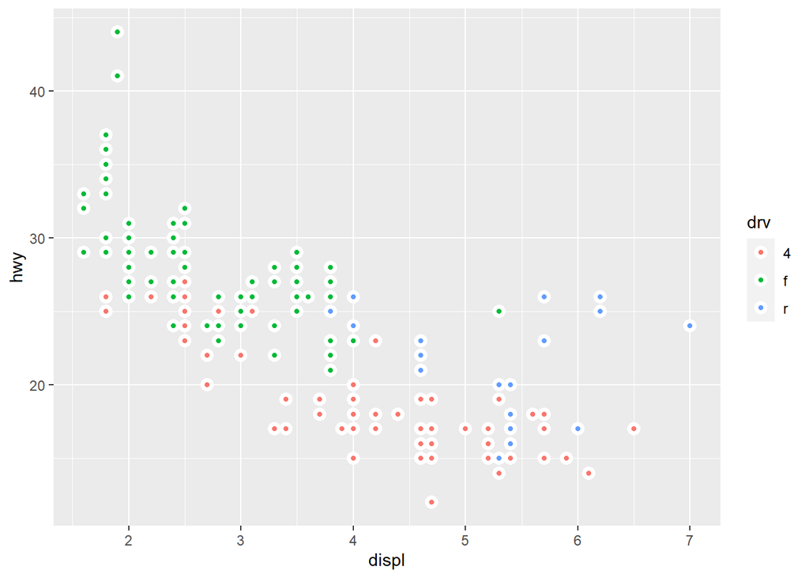

```r
ggplot(data = mpg, aes(x = displ, y = hwy)) +
  geom_point(mapping = aes(fill = drv), color = 'white', stroke = 2, shape = 21)
```

### Textbook 3.7.1

#### Problem 1. What is the default geom associated with stat_summary()? How could you rewrite the previous plot to use that geom function instead of the stat function?

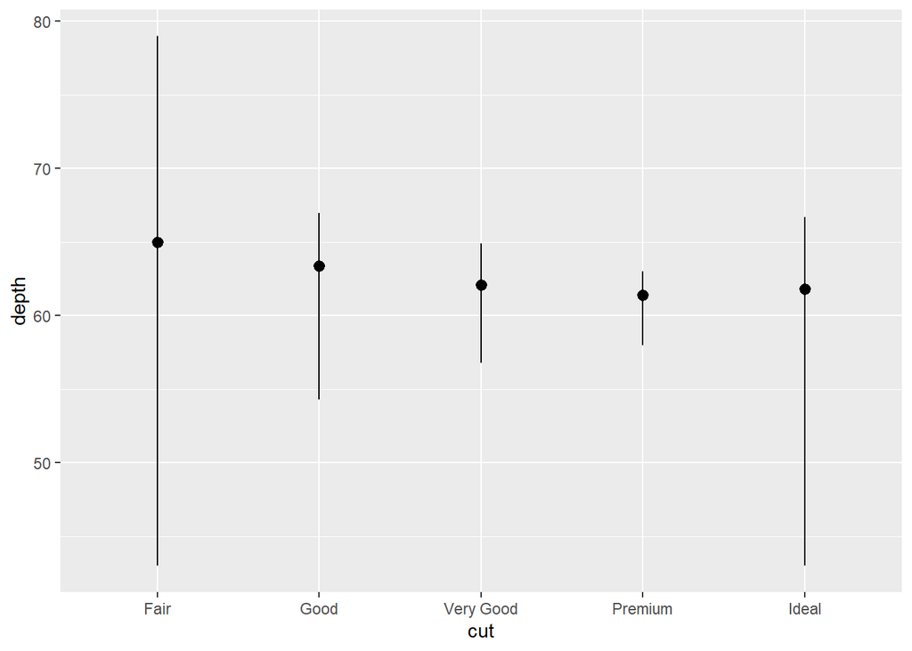

```r
ggplot(data = diamonds) +
  stat_summary(
    mapping = aes(x = cut, y = depth),
    fun.ymin = min,
    fun.ymax = max,
    fun.y = median
  ) # before
```

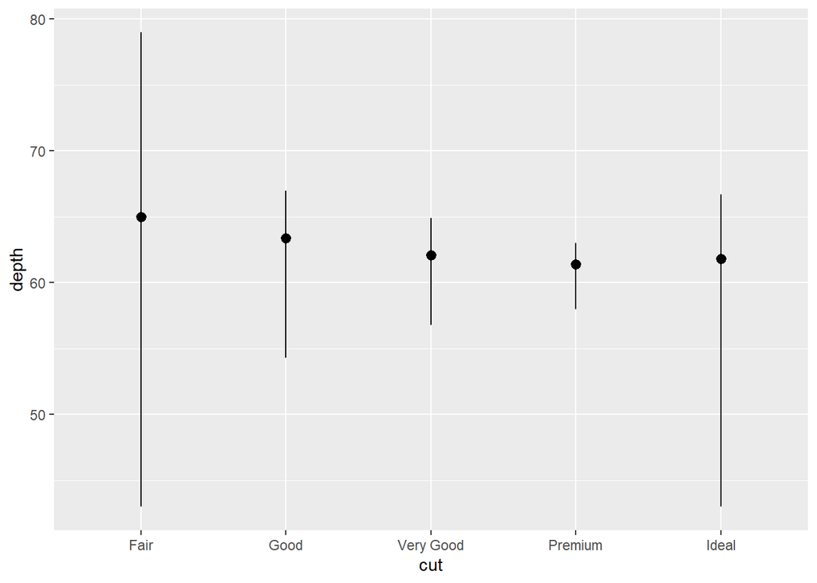

```r
ggplot(data = diamonds) +
  geom_pointrange(
    mapping = aes(x = cut, y = depth),
    stat = "summary",
    fun.min = min,
    fun.max = max,
    fun = median
  ) # after
```

`stat_summary()`의 디폴트 geom은 geom_pointrange이다. `geom_pointrange`는 `ymin` 또는 `ymax` 값을 자동으로 계산하지 않으므로 `stat = "summary"`를 이용해 구할 수 있다. 주어진 코드처럼 x축,y축 설정한 뒤 `stat = "summary"`를 이용해 최솟값, 최댓값, 중앙값 구해주면 이전의 산점도를 그려낼 수 있다.

#### Problem 5. In our proportion bar chart, we need to set group = 1. Why? In other words what is the problem with these two graphs?

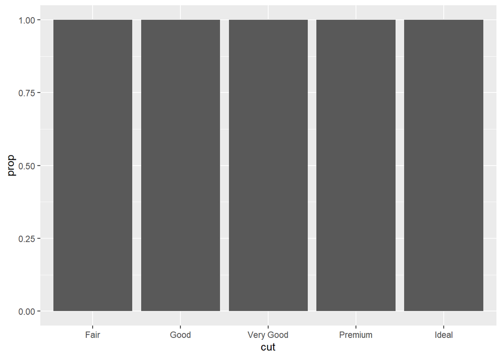

```r
ggplot(data = diamonds) +
  geom_bar(mapping = aes(x = cut, y = ..prop..))
```

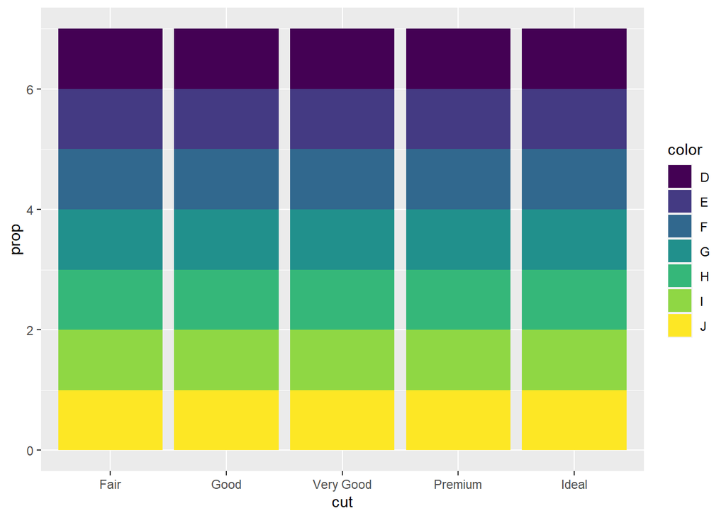

```r
ggplot(data = diamonds) +
  geom_bar(mapping = aes(x = cut, fill = color, y = ..prop..))
```

`group = 1`이라고 지정해주지 않는다면 각 그룹에서 비율은 모두 1이 되어 높이가 다 같아진다. 전체가 1그룹으로 묶여 이들 비율의 합이 1로 묶여야 의미있는 막대그래프를 그릴 수 있을 것이다. 위의 코드들도 이러한 이유로 문제가 발생한 것이다.

### Textbook 3.8.1

#### Problem 1. What is the problem with this plot? How could you improve it?

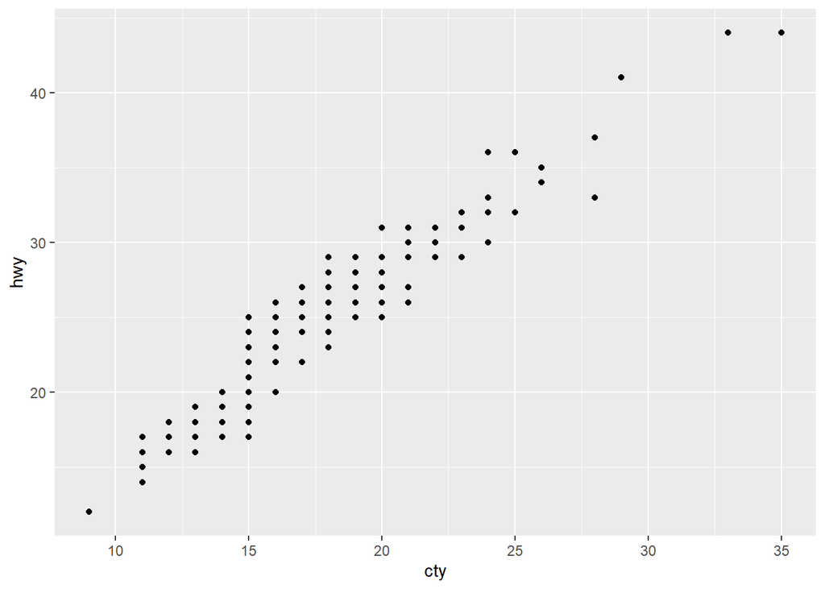

```r
ggplot(data = mpg, mapping = aes(x = cty, y = hwy)) +
  geom_point()
```

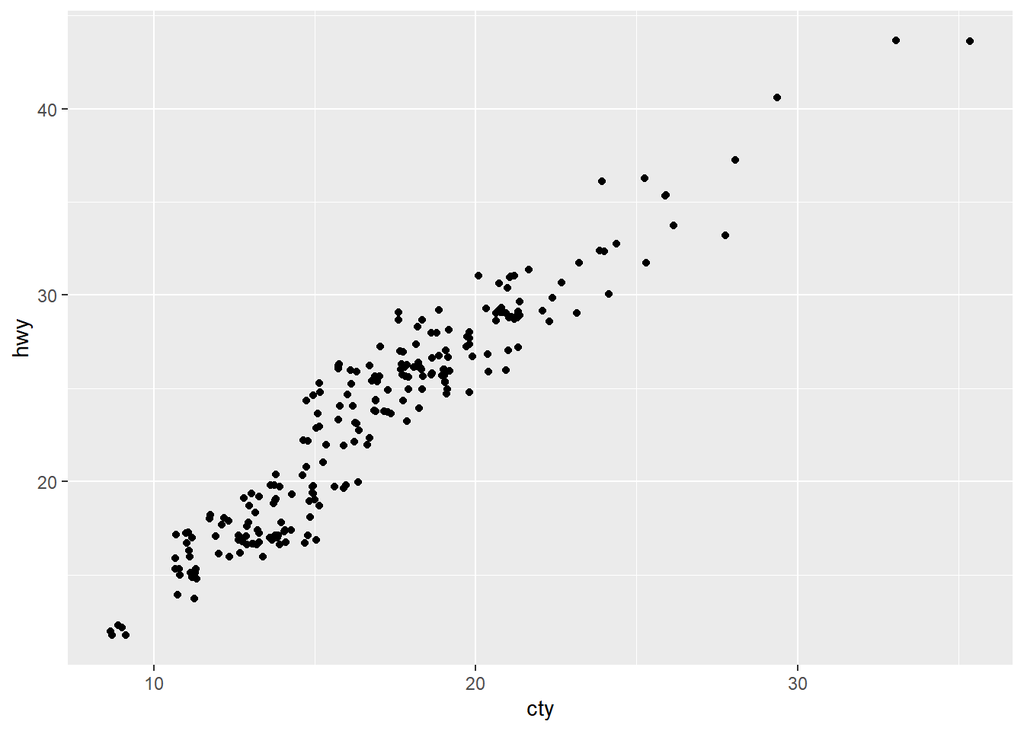

```r
ggplot(data = mpg, mapping = aes(x = cty, y = hwy)) +
  geom_point(position = "jitter")
```

한 점에서 복수의 결과값들이 관찰될 수 있지만 이 산점도에서는 이 부분이 반영되지 못하고 있다. 이럴 때 `position = "jitter"`를 쓰면 문제가 해결될 것이다.

#### Problem 3. Compare and contrast geom_jitter() with geom_count()

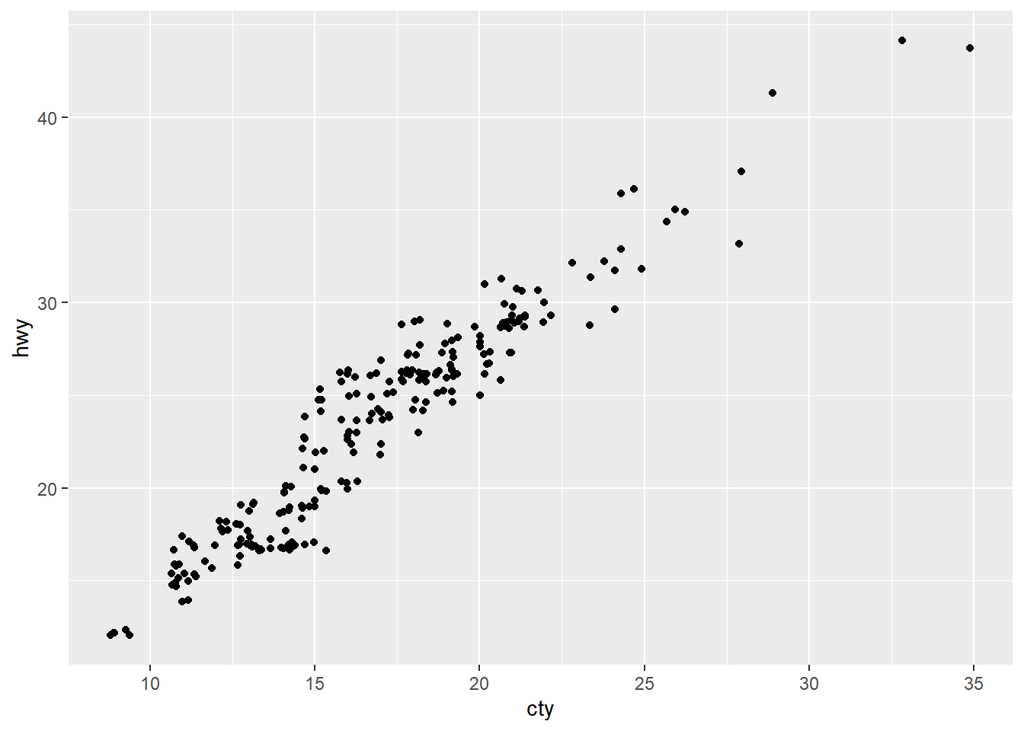

```r
ggplot(data = mpg, mapping = aes(x = cty, y = hwy)) +
  geom_jitter()
```

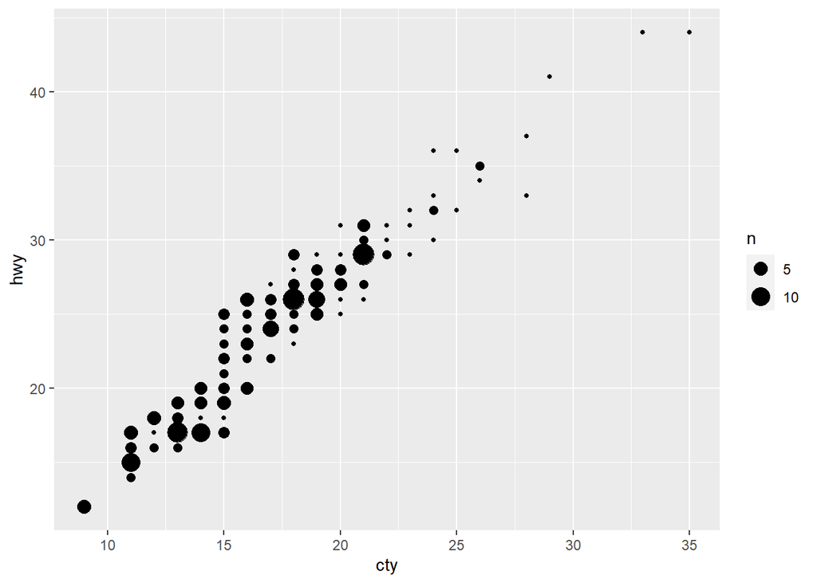

```r
ggplot(data = mpg, mapping = aes(x = cty, y = hwy)) +
  geom_count()
```

두 함수 모두 한 점에서 복수의 결과값들이 관찰될 수 있지만 이것이 산점도에 반영되지 않을 수 있다는 문제점을 해결할 수 있다는 공통점이 있다. 차이점으로는 `geom_jitter()`는 원래 x,y값에 약간 변동이 발생한채로 점들이 산점도에 나타날 수 있지만, `geom_count()`는 x,y값이 변하지 않는 대신 점의 크기가 달라진다.(점의 크기가 클수록 관찰결과 많음)

### Textbook 3.9.1

#### Problem 1. Turn a stacked bar chart into a pie chart using coord_polar().

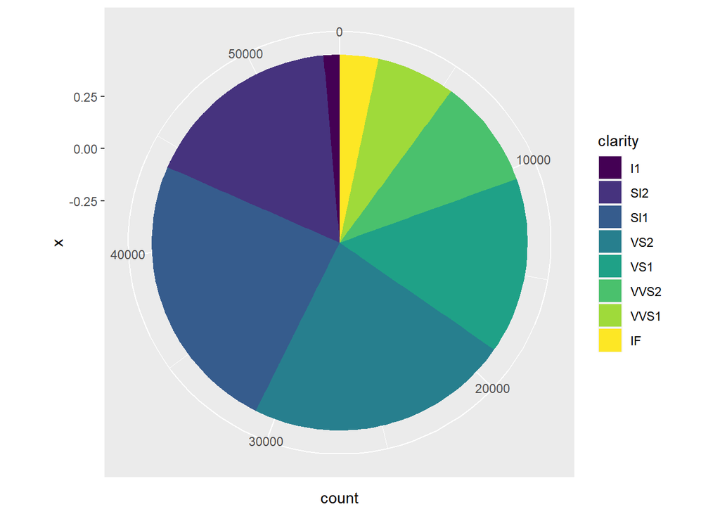

```r
ggplot(data = diamonds,mapping = aes(x = 0, fill = clarity)) +
  geom_bar()+ #before
coord_polar(theta = "y") #추가된 부분
```

#### Problem 4. What does the plot below tell you about the relationship between city and highway mpg? Why is coord_fixed() important? What does geom_abline() do?

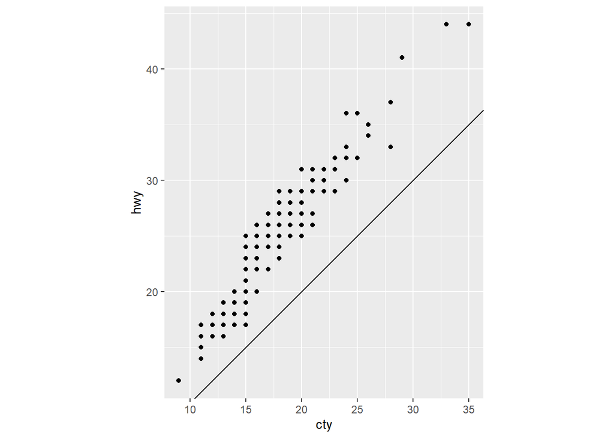

```r
ggplot(data = mpg, mapping = aes(x = cty, y = hwy)) +
  geom_point() +
 geom_abline() +
  coord_fixed()
```

도심에서 연비나 고속도로에서 연비는 비례관계에 있으며 도심에서 연비보다는 고속도로에서 연비가 더 효율적이다. `coord_fixed()`는 축에 있는 데이터 단위의 물리적 표현 사이에 지정된 비율을 강제한다. 비율은 x축의 1개 단위에 해당하는 y축의 단위 수를 나타낸다. 기본값인 비율 = 1은 x축의 한 단위가 y축의 한 단위와 같은 길이를 갖도록 한다. 그러므로 `coord_fixed()`를 통해 기준선의 각이 45도가 되어 산점도를 이해하기 더 쉬워진다. `geom_abline()`은 수평, 수직 또는 대각선(경사와 절편에 의해 지정됨) 중 하나에 기준선을 추가하는 역할을 한다.

### Textbook 6.3

#### Problem 2. What other common mistakes will RStudio diagnostics report? Read https://support.rstudio.com/hc/en-us/articles/205753617-Code-Diagnostics to find out.

변수가 생성되었지만 사용되지 않는 것이 있는지를 체크해준다. 이는 이전 코드를 정리하거나 다른 오류(특정 변수를 사용해야 한다고 생각하지만 그렇지 않은 경우)를 찾고자할 때 유용하다. (페이지에서 얻을 수 있는 정보)

### Textbook 28.2.1

#### Problem 1. Create one plot on the fuel economy data with customised title, subtitle, caption, x, y, and colour labels.

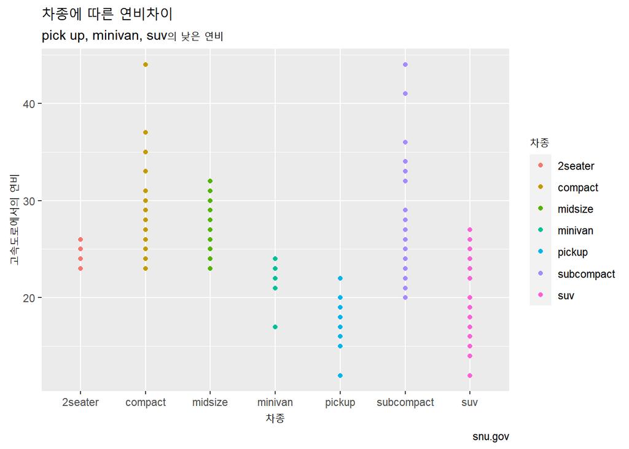

```r
ggplot(data = mpg,mapping = aes(x = class, y = hwy, color = class))+
  geom_point()+
 labs(
    title = "차종에 따른 연비차이",
    subtitle = "pick up, minivan, suv의 낮은 연비",
    caption = "snu.gov",
    x = "차종",
    y ="고속도로에서의 연비",
    colour = "차종"
  )
```

### Textbook 28.4.4

#### Problem 4 Use override.aes to make the legend on the following plot easier to see.

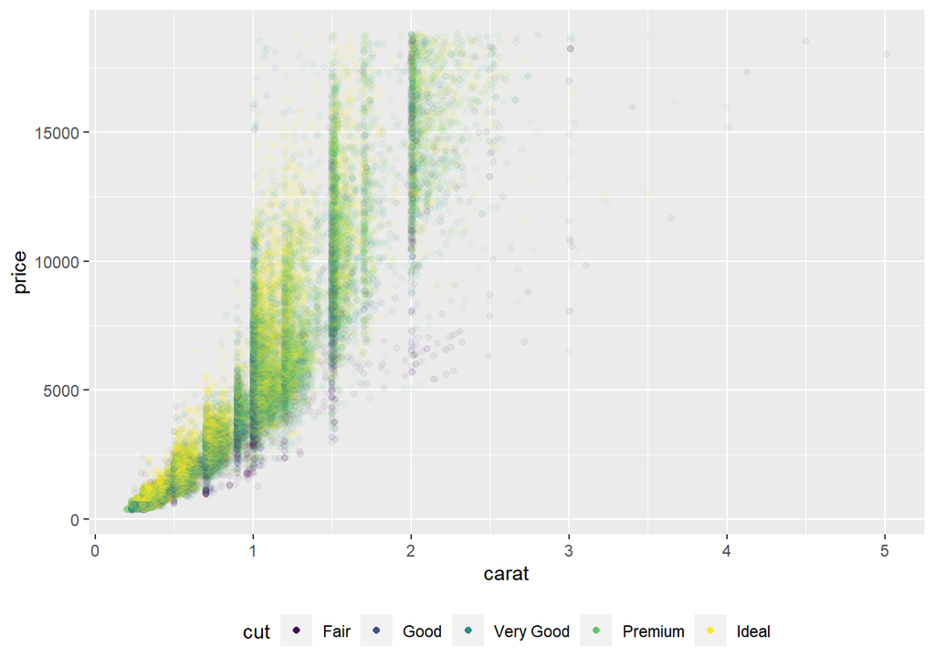

```r
ggplot(diamonds, aes(carat, price)) +
  geom_point(aes(colour = cut), alpha = 1/20)+ # before
 theme(legend.position = "bottom") +
  guides(colour = guide_legend(override.aes = list(alpha = 1))) #add
```

투명도를 조절해 범례를 더 잘 보이게 할 수 있다. 그러므로 `override.aes`를 이용해 `alpha`값을 조정해줘야한다.

```r
x<-5
y<-6 #a
log(x+y) #b
```

```
## [1] 2.397895
```

```r
log10(x*y/2) #c
```

```
## [1] 1.176091
```

```r
x^(1/3)+2*y^(1/4) #d
```

```
## [1] 4.840145
```

```r
10^(x-y)+exp(x+y) #e
```

```
## [1] 59874.24
```